# Programming in R (OC+DL): Solution for exam part 2 (15/01/2024)

### Solution 7.3

```r
q7_2.df %>%
  summarise_all(funs(sum(is.na(.))))
```

```
## # A tibble: 1 × 10
##     PID Clinic Group   Age Education   BMI Birthweight clinic Hypertension
##   <int>  <int> <int> <int>     <int> <int>       <int>  <int>        <int>
## 1     0      0     0     0         0    73          14     23           23
## # ℹ 1 more variable: Diabetes <int>
```

```r
q7_3.df <- q7_2.df %>%
  filter(complete.cases(.))
dim(q7_3.df)
```

```
## [1] 694  10
```

4. Produce Figure 7.1 and Figure 7.2 below and calculate the correlation between `BMI` and `Birthweight` for individuals from group C and individuals from group T (for each group separately, you can make the selection based on the variable `Group`).

### Solution 7.4

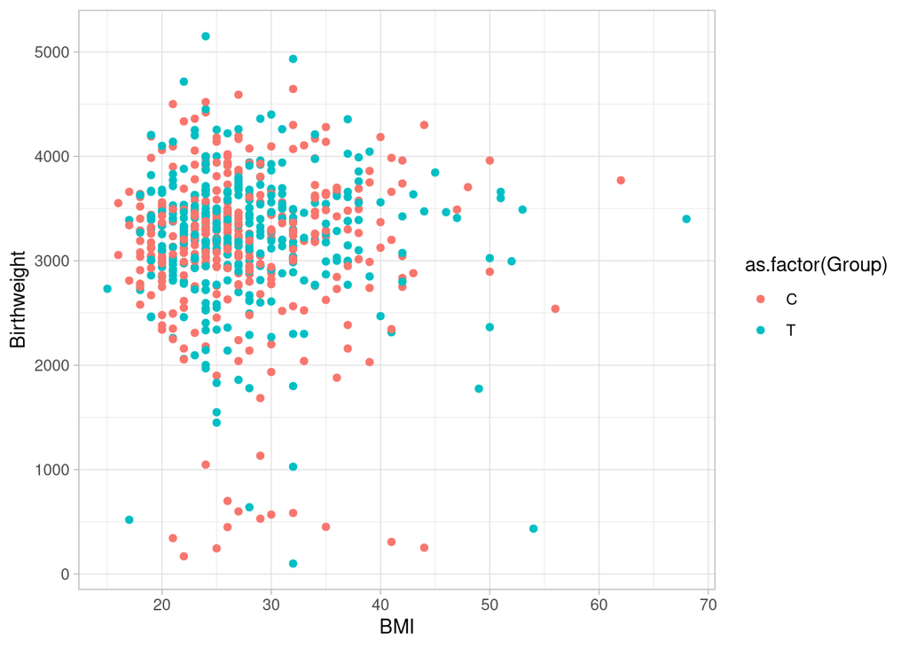

```r
ggplot(q7_3.df, aes(x = BMI, y = Birthweight, color=as.factor(Group))) +
  geom_point() +
  theme_light()
```

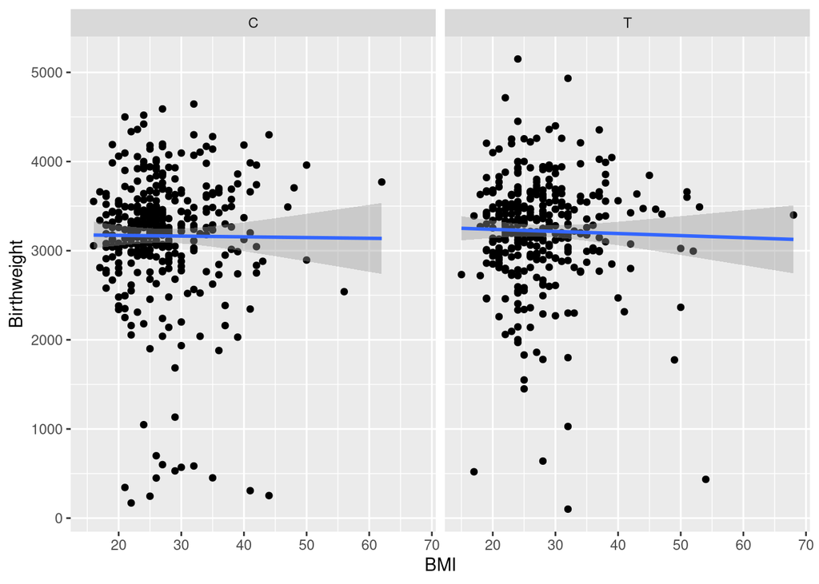

```r
ggplot(q7_3.df, aes(x = BMI, y = Birthweight)) +
  geom_point() +
  facet_wrap(~Group) +
  stat_smooth(method = "lm", se = T, formula = y ~ x)
```

```r
paste("group C")
```

```
## [1] "group C"
```

```r
cor(q7_3.df$BMI[q7_3.df$Group == "C"], q7_3.df$Birthweight[q7_3.df$Group == "C"])
```

```
## [1] -0.007758347
```

```r
paste("group T")
```

```
## [1] "group T"
```

```r
cor(q7_3.df$BMI[q7_3.df$Group == "T"], q7_3.df$Birthweight[q7_3.df$Group == "T"])
```

```
## [1] -0.02672523
```

5. Use the merged data that you created in Question 7.3 to create a new data frame for all individuals older than 25 years old. How many observations are included in the new dataset? Produce Figure 7.3 for the new data which presents the Age Vs. Birthweight for each level of Diabetes colored by education level.

### Solution 7.5

```r
q7_5.df <- q7_3.df %>%
  filter(Age > 25)
nrow(q7_5.df)
```

```
## [1] 323
```

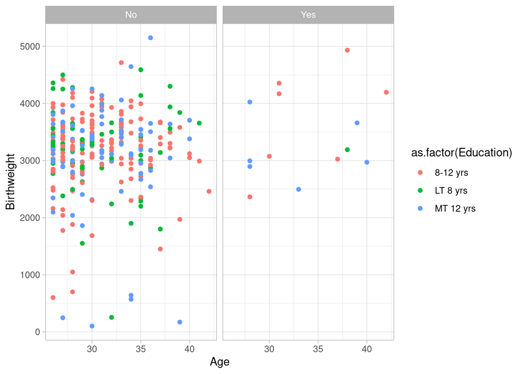

```r
ggplot(q7_5.df, aes(x = Age, y = Birthweight, color=as.factor(Education))) +
  geom_point() +
  theme_light() +
  facet_wrap(~Diabetes)
```

6. Fit a linear regression model which includes the effect of the treatment group (the variable `Group`), hypertension and diabetes on the birth weight.

### Solution 7.6

```r
lm(Birthweight ~ Group + Hypertension + Diabetes, data = q7_3.df)
```

```
##
## Call:
## lm(formula = Birthweight ~ Group + Hypertension + Diabetes, data = q7_3.df)
##
## Coefficients:
##     (Intercept)           GroupT  HypertensionYes      DiabetesYes
##         3170.64            55.71          -367.32           267.92
```

7. Use the merged data that you created in Question 7.3 to create a new data frame for all individuals participated in the Intervention (T) group from Enrollment Center: Harlem Hospital (NY). For selection, you can use the variable `Clinic`.

### Solution 7.7

```r
q7_7.df <- q7_3.df %>%
  filter(Group == "T" & Clinic == "NY")
nrow(q7_7.df)
```

```
## [1] 53
```

8. Produce Figure 7.4, to visualize the infant birth weight at time of birth of each participant.

### Solution 7.8

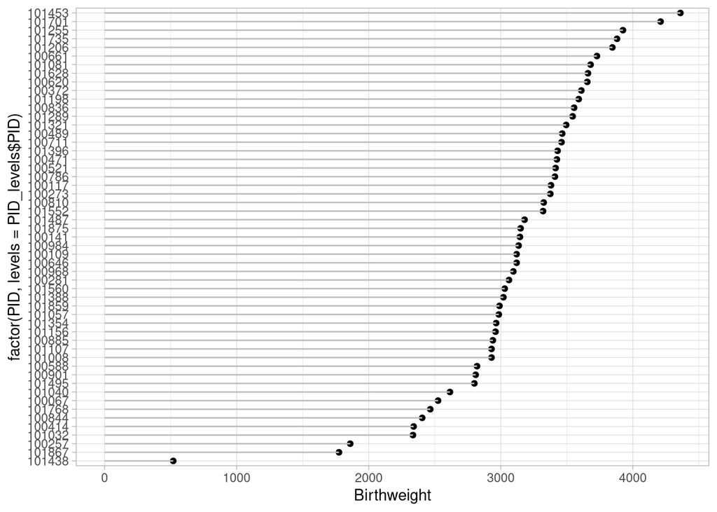

```r
PID_levels <- q7_7.df%>%
  arrange(Birthweight) %>%
  select(PID)
ggplot(q7_7.df, aes(x = factor(PID, levels=PID_levels$PID), y = Birthweight)) +
  geom_point() +
  theme_light() +
  geom_segment(aes(xend = factor(PID, levels=PID_levels$PID), y = 0, yend = Birthweight), color = "grey") +
  coord_flip()
```

9. Highlight participants who had chronic hypertension at baseline with different color as shown in Figure 7.5.